# Chapter-10.3

10H3. The data contained in library(MASS);data(eagles) are records of salmon pirating attempts by Bald Eagles in Washington State. See ?eagles for details. While one eagle feeds, sometimes another will swoop in and try to steal the salmon from it. Call the feeding eagle the “victim” and the thief the “pirate.” Use the available data to build a binomial GLM of successful pirating attempts.

```r
library(MASS);data(eagles)
library(ggplot2)
?eagles
summary(eagles)
```

```
##        y               n         P     A     V
##  Min.   : 0.00   Min.   : 4.00   L:4   A:4   L:4
##  1st Qu.: 1.00   1st Qu.:15.00   S:4   I:4   S:4
##  Median :16.00   Median :22.00
##  Mean   :12.50   Mean   :20.00
##  3rd Qu.:17.75   3rd Qu.:27.25
##  Max.   :29.00   Max.   :29.00
```

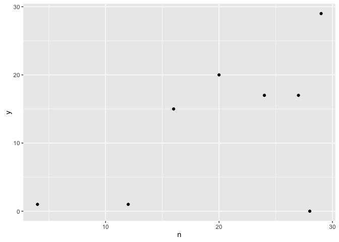

```r
qplot(x=n,y=y, data=eagles)
```

```r
library(rethinking)
```

```r
d <- eagles
d$P <- ifelse( d$P=="L" , 1 , 0 )
d$V <- ifelse( d$V=="L" , 1 , 0 )
d$A <- ifelse( d$A=="A" , 1 , 0 )

m10.3hA <- map(
    alist(
         y ~ dbinom(n , p ) ,
        ## do we want to leave one of these out....
         logit(p) <- a + bp*P + ba*A + bv*V,
        a ~ dnorm(0,10),
        bp ~ dnorm(0,1),
        ba ~ dnorm(0,1),
        bv ~ dnorm(0,1)
),
data=d)


m10.3hA.stan <- map2stan(
    alist(
         y ~ dbinom(n , p ) ,
        ## do we want to leave one of these out....
         logit(p) <- a + bp*P + ba*A + bv*V,
        a ~ dnorm(0,10),
        bp ~ dnorm(0,1),
        ba ~ dnorm(0,1),
        bv ~ dnorm(0,1)
),
data=d)
```

[output not shown]

[output cut: 20 more lines]

[output not shown]

```
## Computing WAIC
```

```
## Constructing posterior predictions
```

[output not shown]

```
## Aggregated binomial counts detected. Splitting to 0/1 outcome for WAIC calculation.
```

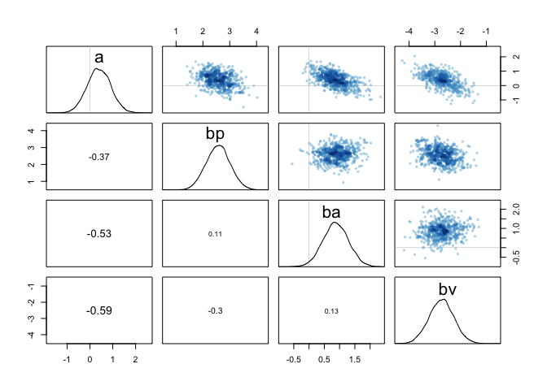

```r
pairs(m10.3hA)
```

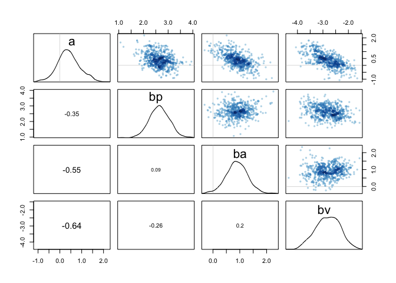

```r
pairs(m10.3hA.stan)
```

Yes we can tell from the pairs plot that using quadratic approximation is okay!

2. Now interpret the estimates. If the quadratic approximation turned out okay, then it’s okay to use the map estimates. Otherwise stick to map2stan estimates. en plot the posterior predictions. Compute and display both (1) the predicted probability of success and its 89% interval for each row (i) in the data, as well as (2) the predicted success count and its 89% interval. What different information does each type of posterior prediction provide?

```r
#y.seq <- seq(from=0,to=30,by=1)
#n.seq <- seq(from=0,to=30,by=1)
#a = rep(c(0,1,1,0), times=31)
#v= rep(c(0,1,0,1), times=31)
#p = rep(c(0,1,0), times=31)
d.pred <- d
mu.m10.3hA <- link( m10.3hA , d)
```

[output not shown]

```r
mu.m10.3hA.mean <- apply( mu.m10.3hA , 2 , mean )
mu.m10.3hA.PI <- apply( mu.m10.3hA , 2 , PI , prob=0.97 )
```

They each represent each of the combinations of P,A and V

3. Now try to improve the model. Consider an interaction between the pirate’s size and age (immature or adult). Compare this model to the previous one, using WAIC. Interpret.

```r
m10.3hB <- map(
    alist(
         y ~ dbinom(n , p ) ,
        ## do we want to leave one of these out....
         logit(p) <- a + bP*P + bA*A + bV*V + bPA * P*A,
        a ~ dnorm(0,10),
        bP ~ dnorm(0,1),
        bA ~ dnorm(0,1),
        bV ~ dnorm(0,1),
        bPA ~ dnorm(0,1)
),
data=d)

compare(m10.3hA,m10.3hB)
```

```
##          WAIC pWAIC dWAIC weight   SE  dSE
## m10.3hA 104.6   2.3   0.0   0.52 9.63   NA
## m10.3hB 104.8   2.7   0.2   0.48 9.58 0.35
```

## Example from Julin

The attached data sheet is from Liron and records germination for M82 and pen at two temperatures

```r
l <- read.csv("/Users/gturco/Documents/2011_2016_PHD/code/Rclub-rethinking_Gina.Turco/Assignment_Chapter_10/LironDataTime1.csv",header=TRUE)

summary(l)
```

```
##       Time    Temperature    Plate..    Species  Germination
##  Min.   :1   Min.   :14   Min.   :1.0   M82:60   No :38
##  1st Qu.:1   1st Qu.:14   1st Qu.:2.0   pen:60   Yes:82
##  Median :1   Median :18   Median :3.5
##  Mean   :1   Mean   :18   Mean   :3.5
##  3rd Qu.:1   3rd Qu.:22   3rd Qu.:5.0
##  Max.   :1   Max.   :22   Max.   :6.0
##   Root.length      Shoot.length
##  Min.   :0.0000   Min.   :0.0000
##  1st Qu.:0.0000   1st Qu.:0.0000
##  Median :0.4650   Median :0.0000
##  Mean   :0.6824   Mean   :0.2863
##  3rd Qu.:1.1325   3rd Qu.:0.7025
##  Max.   :2.9000   Max.   :1.5300
```

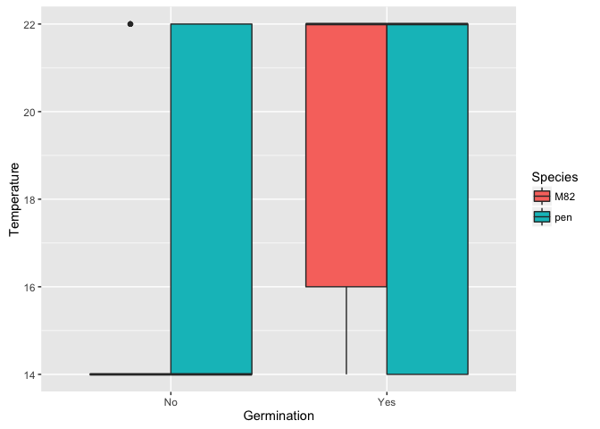

```r
### germination yes or no event, this is a proablity of happening not a low sucess rate (not poisson) and using count data- binomial


### not sure this are showing me anything would be better to plot prob of yes and no....
ggplot(data=l, aes(x=Germination,y=Temperature,fill=Species)) + geom_boxplot(position="dodge")
```

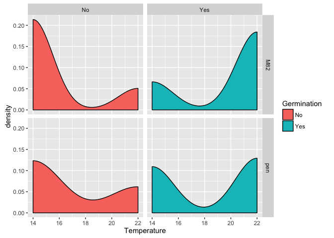

```r
ggplot(data=l, aes(fill=Germination,x=Temperature)) + geom_density() + facet_grid(Species~Germination)
```

Perform a Bayesian analysis to determine whether or not the two species have different germination rates, whether temperature affects germination, and whether there is a temperature by germination interaction.

```r
### germination yes or no event
d <- data.frame(Germination=ifelse(l$Germination=="Yes",1,0), Temperature=l$Temperature, Species=ifelse(l$Species=="M82",1,0))

### is this one trail for each of these


### how do we adjust the coiffent range should it be count or prob or logit..
#m10.liron <- map(
#    alist(
#          ### is this one trail for each of these
#         Germination ~ dbinom(1,p) ,
#         logit(p) <- a + bT*Temperature + bS*Species + bTS * Temperature*Species,
#        a ~ dnorm(0,100),
#        ## is the temp in cel...
#        bT ~ dnorm(0,100),
#        bS ~ dnorm(0,100),
#        bTS ~ dnorm(0,100)
#),
#data=l)

m10.liron.stan <- map2stan(
    alist(
          ### is this one trail for each of these
         Germination ~ dbinom(1,p) ,
         logit(p) <- a + bT*Temperature + bS*Species + bTS * Temperature*Species,
        a ~ dnorm(0,100),
        ## is the temp in cel...
        bT ~ dnorm(0,100),
        bS ~ dnorm(0,100),
        bTS ~ dnorm(0,100)
),
data=d)
```

[output not shown]

[output cut: 20 more lines]

[output not shown]

```
## Computing WAIC
```

```
## Constructing posterior predictions
```

[output not shown]